# Capsule 1 - Distinguer tendance et saisonnalité

MQT-2101 - Analyse et modélisation des données

## Pourquoi ça compte

Un niveau qui monte peut masquer des mois systématiquement forts ou faibles.

Comment séparer l’évolution de long terme des effets de calendrier?

La tendance change graduellement le niveau. La saisonnalité est un motif récurrent à une fréquence connue. Les deux peuvent être présents simultanément.

## Objectifs de la capsule

- Définir tendance et saisonnalité.
- Chercher une récurrence sur plusieurs cycles.
- Comparer les mêmes mois sur plusieurs années.

## Tendance et saisonnalité répondent à deux questions

- Une seule année ne prouve pas la saisonnalité.
- Comparer les mêmes mois sur plusieurs années.
- La tendance peut modifier le niveau général.

## Comparer janvier avec janvier

Regrouper les observations de janvier permet de comparer janvier d’une année à l’autre malgré une tendance globale.

## Visualiser les mois sur plusieurs années

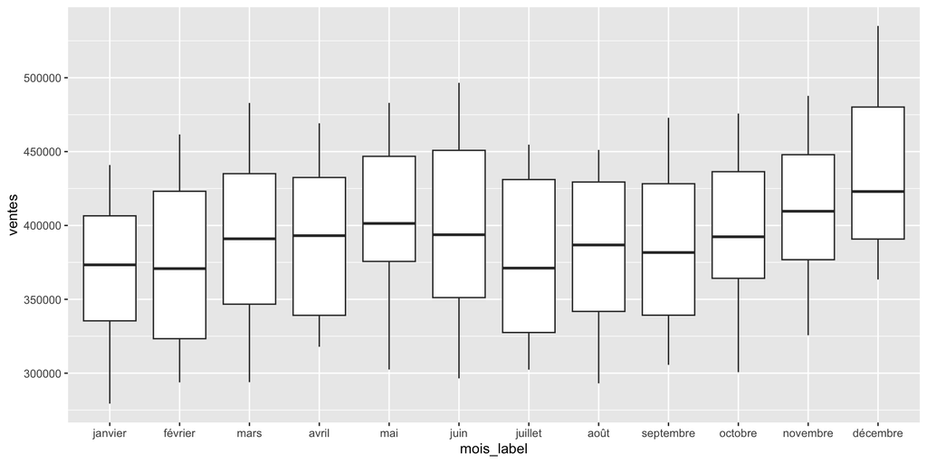

```r
ventes |> ggplot(aes(mois_label, ventes)) +
  geom_boxplot()
```

## Une seule année ne prouve pas une saisonnalité

Interpréter une hausse de janvier à décembre dans une seule année comme une saisonnalité confond un trajet unique et un motif récurrent.

## À retenir

1

La tendance est un mouvement de long terme.

2

La saisonnalité revient selon un calendrier.

3

La décision reste liée aux données disponibles.

## Production autonome 8.1

Expliquez pourquoi il est utile de comparer toutes les observations de janvier.

### Auto-vérification

- Toutes les méthodes utilisent la même période de validation.
- J’ai interprété l’erreur dans son unité.
- J’ai relié le résultat à une décision et à une limite.